# Ford Go Bike Analysis

### What is the gender profile of bike renters?

- 74% of the total bike rentals are done by men
- 24% by females. Gender ratio between male and female is approximately 3:1.
- There a small percentage that belongs to other category but we can ignore it for analysis purposes.

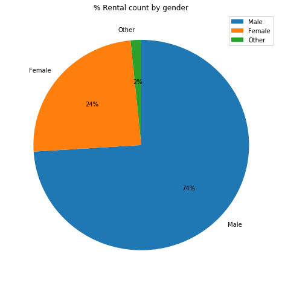

```python
ax = \
df[['bike_id', 'member_gender']]\
.groupby('member_gender')\
.agg({'bike_id': 'count'})\
.reset_index()\
.rename(columns={'bike_id': 'rental_count'})\
.sort_values(by=['rental_count'], ascending=[False])\
.reset_index(drop=True)\
.set_index('member_gender')\
.plot.pie(y=0,
          autopct='%1.0f%%',
          startangle=90,
          counterclock=False,
          figsize=(8, 8))

ax.set_title('% Rental count by gender');
ax.set_ylabel('');
```

### How is the business doing in past few years?

- Cumulative values of rental volume, distance biked in miles and bike ride duration in hours show steady upward trend with almost equal slope indicating growth of business.
- There is growth spurt from April 2018 till October 2018 showing relatively higher growth rate compared to same period in previous year. After October 2018, rental business shows signs of slow down.

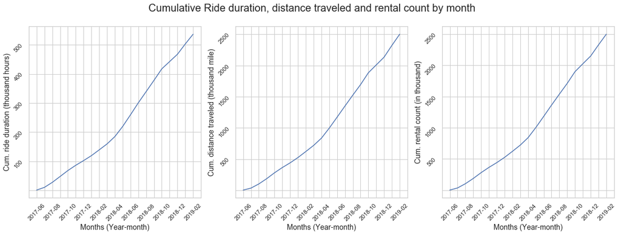

```python
# Visualization of monthly metrics
fig, ax = plt.subplots(1, 3, figsize=(20,6),sharex=True)
fig.suptitle('Cumulative Ride duration, distance traveled and rental count by month', fontsize=20)

metrics = ['cumulative_duration_hours','cumulative_distance_in_mile', 'cumulative_rental_count']
for i,j in enumerate(range(len(ax))):
    sns.set(style="whitegrid")
    g = sns.lineplot(x="end_time_year_month", y=metrics[i], data=monthly_metric_df, ax=ax[j])

y_labels = ['Cum. ride duration (thousand hours)', 'Cum. distance traveled (thousand mile)', 'Cum. rental count (in thousand)']

xtick_labels = [x if index % 2 == 0 else '' for index, x in enumerate(monthly_metric_df.end_time_year_month.unique().tolist())]
for i in range(len(ax)):
    ax[i].tick_params(labelrotation=45)
    ax[i].set_xticklabels(xtick_labels)
    ax[i].set_ylabel('%s' % y_labels[i], fontsize=14)
    scale_yaxis(ax[i])
    ax[i].set_xlabel('Months (Year-month)', fontsize=14)


# Hack to eliminate empty grids at the end
for i in range(2,5):
    plt.close(i)
```

### Does rental volume show seasonality?

- Bike rental volume goes down during winter season which is also the season when it rains.
- Dip in monthly volume can be observed in November & December 2017 and repeating itself during same months in 2018.

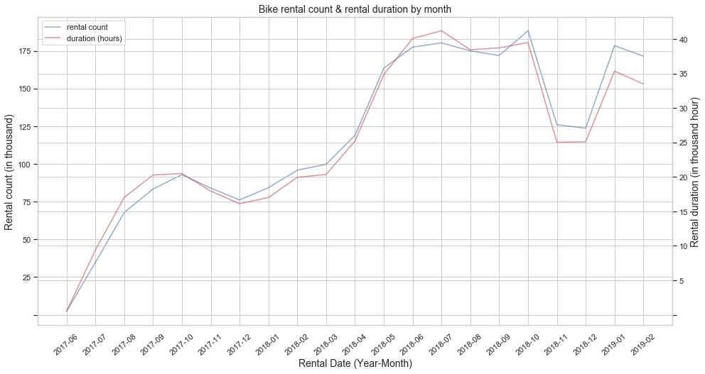

```python
# Line graph visualization for monthly bike rental count and biked duration plotted in dual-axis graph
fig, ax = plt.subplots(figsize=(16,8))

line1 = ax.plot(monthly_metric_df.end_time_year_month, monthly_metric_df.rental_count, alpha=0.6, c='b')

ax.set_xticklabels([x for x in monthly_metric_df.end_time_year_month], rotation=40)
ax.set_title('Bike rental count & rental duration by month', fontsize=14)
ax.set_xlabel('Rental Date (Year-Month)', fontsize=14)
ax.set_ylabel('Rental count (in thousand)',fontsize=14)
scale_yaxis(ax)

ax2 = ax.twinx()
line2 = ax2.plot(monthly_metric_df.end_time_year_month, monthly_metric_df.duration_sec / (60 * 60), c='r', alpha=0.6)
ax2.set_ylabel('Rental duration (in thousand hour)',fontsize=14);
h1, l1 = ax.get_legend_handles_labels()
h2, l2 = ax2.get_legend_handles_labels()
scale_yaxis(ax2)
plt.legend(h1 + h2, ['rental count', 'duration (hours)'], loc=2);
```

To factor out the effect of seasonality, instead of comparing with previous month business metrics are compared with same month in previous year. For example October 2018 is compared in October 2017. Percent increase of the metric value from same month in previous year is used as basis and posted as annotation.

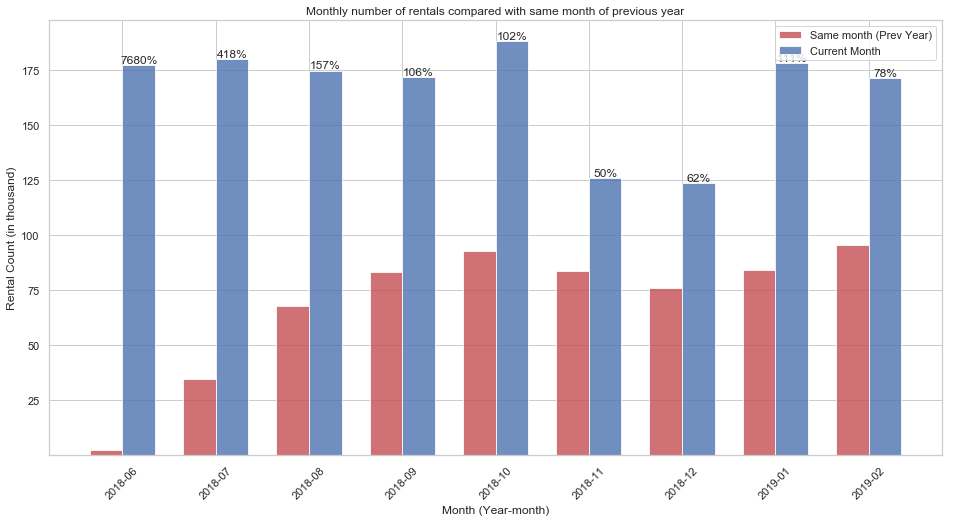

```python
# Visualization of monthly rental volume compared to data from same month last year
fig, ax = plt.subplots(figsize=(16,8))
width = 0.35
ind = np.arange(len(seasonal_df.year_month.tolist()))
plt.bar(
    ind,
    seasonal_df.ly_same_month_rental_count,
    alpha=0.8,
    color='r',
    width=width
);
ax2 = plt.bar(
    ind + width,
    seasonal_df.rental_count,
    alpha=0.8,
    color='b',
    width=width
);

labels = map(lambda x: str(x) + '%', seasonal_df.pct_increase.tolist())

plt.legend(['Same month (Prev Year)', 'Current Month'])
plt.xticks(ind + width / 2.0, seasonal_df.year_month.tolist(), rotation=45);

plt.ylabel('Rental Count (in thousand)')
plt.xlabel('Month (Year-month)')
plt.title('Monthly number of rentals compared with same month of previous year')
scale_yaxis(plt.gca())

for rect, label in zip(ax2.patches, labels):
    height = rect.get_height()
    ax.text(rect.get_x() + rect.get_width() / 2, height + 5, label,
            ha='center', va='bottom')
```

- Bike rental business shows periodicity with respect to day of week.
- Number of rentals are lowest over the weekend - Saturday & Sunday. Monday & Friday are relatively low volume days compared to middle of the week.
- This brings an interest guess about the purpose of bike rental - whether the main usage is - pleasure or business use? The fact that the volume of business goes down drastically over the weekend and surges during middle of the week is indicative that the prime usage is for commuting to office.

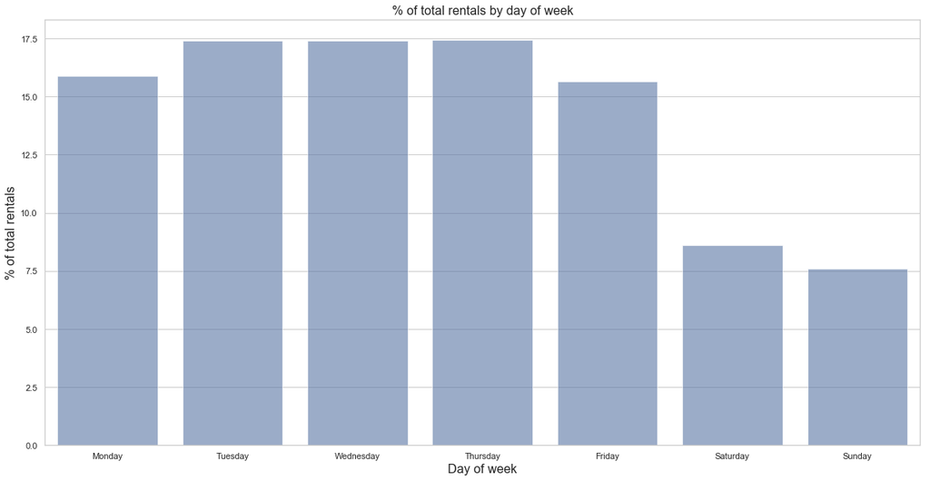

```python
plt.subplots(figsize=(20,10))
sns.set(style="whitegrid")
g = sns.barplot(x="day_of_week",
                 y="pct_of_total",
                 data=day_agg_df,
                 color=sns.color_palette()[0],
                 alpha = 0.6)
g.set_xlabel('Day of week', fontsize=16)
g.set_ylabel('% of total rentals', fontsize=16)
g.set_title('% of total rentals by day of week', fontsize=16);
```

- Rental behavior of `customers` is different from that of `subscribers`.
- Rental volume of customers increases during the weekend. One hypothesis is - this group rent bike primarily for leisure usage.

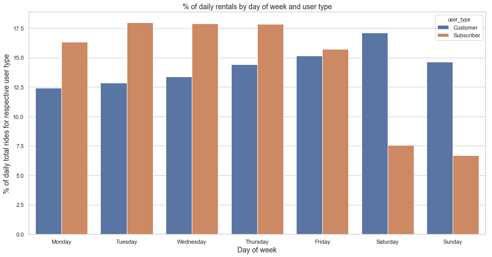

```python
fig, ax = plt.subplots(figsize=(16, 8))
sns.set(style="whitegrid")
g = sns.catplot(
    x="day_of_week",
    y="pct_of_total",
    hue="user_type",
    data=day_agg_df,
    kind="bar",
    ax=ax)
ax.set_xlabel('Day of week', fontsize=14)
ax.set_ylabel('% of daily total rides for respective user type', fontsize=14)
ax.set_title('% of daily rentals by day of week and user type', fontsize=14);
plt.close(2)
```

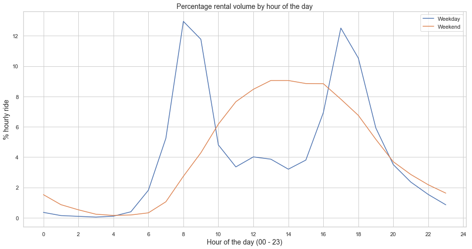

```python
fig, ax = plt.subplots(figsize=(16,8))
sns.lineplot(data=hourly_df,
             x='end_time_hour',
             y='pct_hourly_rental',
             hue='is_weekend',
             estimator=None);
ax.set_ylabel('% hourly ride', fontsize=14)
ax.set_title('Percentage rental volume by hour of the day', fontsize=14);
ax.set_xlabel('Hour of the day (00 - 23)', fontsize=14)
plt.xticks(np.arange(0, 26, 2))
ax.legend(['Weekday', 'Weekend']);
```

- Following group of four heat maps are corresponding 4 user segments - female customer, female subscriber, male customer & male subscriber. The annotations in the heat map show the median value of the bike rental count for age groups between 20 - 40 years.
- Rental pattern shows non-subscribers are primarily using the rental during the weekend and subscribers are using it during regular commute hours between Monday through Friday.

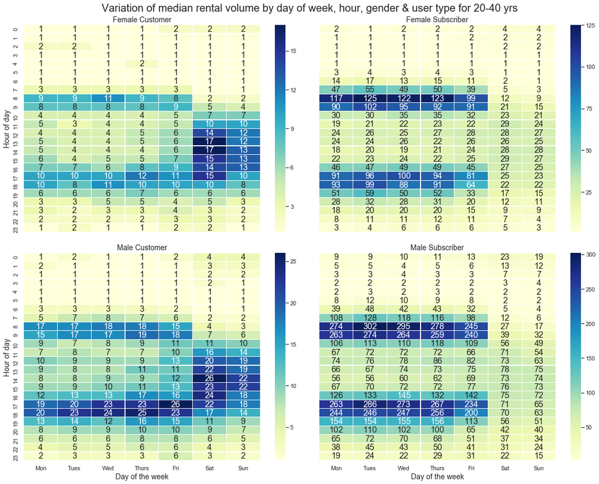

```python
fig, ax = plt.subplots(2, 2, figsize=(20, 14), sharex="col", sharey="row")
fig.suptitle('Variation of median rental volume by day of week, hour, gender & user type for 20-40 yrs', fontsize=20)
user = day_hour_rental_df.user.unique().tolist()
plt.subplots_adjust(wspace=0, hspace=.1, top=0.94)
index = 0
for j in range(len(ax)):
    for i in range(len(ax[j])):
        temp_df = day_hour_rental_df.query("user == '%s'" % user[index])[['end_time_hour', 'Monday', 'Tuesday', 'Wednesday', 'Thursday', 'Friday', 'Saturday', 'Sunday']]
        temp_df = temp_df.set_index('end_time_hour')
        index = index + 1
        g = sns.heatmap(temp_df, annot=True, fmt="d", linewidths=.2, cmap="YlGnBu", annot_kws={"size":16}, ax=ax[j][i]);

index = 0
for j in range(len(ax)):
    for i in range(len(ax[j])):
        if i == 0:
            ax[j][i].set_ylabel('Hour of day', fontsize=14)
        else:
            ax[j][i].set_ylabel('')
        ax[j][i].set_title('%s' % user[index], fontsize=14)
        index = index + 1
        if j == len(ax) - 1:
            ax[j][i].set_xlabel('Day of the week', fontsize=14)
            ax[j][i].set_xticklabels(['Mon', 'Tues', 'Wed', 'Thurs', 'Fri', 'Sat', 'Sun'])
        else:
            ax[j][i].set_xlabel('')
```

## Conclusion

- Ford Go Bike rental is flourishing as bike rental business. It is showing healthy signs of growth.
- Male to female gender ratio for bike rental is 3:1.
- Prime usage of the bike rental is for office commuting. These users subscribe to monthly plan.
- Leisure users' usage and rental pattern are different from daily office commuters.
- Seasonality affects the business specially during winter months.
- Weekend demand is lower than weekday demand.